# STAT 240 Discussion 3

## Group 319E (use the assigned group name/number)

## Members Present

- Shruthi Srinivasan, Zheng Ma, Ziling Hu
- **Haoxuan Lu**

## Questions

### 1

> Write code to modify the exoplanet data by doing the following:
1. Remove all rows for which the variable `default_flag` is 0. We are going to work with exoplanets that have been published confirmed and contain the default parameter values for the planet. This will produce a data frame where each row corresponds to only one planet.
2. Change the names of the variables `pl_name` to `planet`, `hostname` to `star`, `discoverymethod` to `method`, `disc_year` to `year`, `sy_pnum` to `number`, `pl_rade` to `radius`, and `pl_bmasse` to `mass`. Keep these variables and eliminate the other variables.
3. Count the number of discoveries by method and eliminate rows with discovery methods that have fewer than 20 discoveries.

```r
planets <- read_csv("exoplanets-3sept2020.csv") %>%
  select(pl_name, hostname, discoverymethod, disc_year, sy_pnum, pl_rade, pl_bmasse, default_flag) %>%
  rename(planet=pl_name, star=hostname, method=discoverymethod,year=disc_year, number=sy_pnum, radius=pl_rade, mass=pl_bmasse) %>%
  filter(default_flag!=0)

planets %>%
  count(method)
```

```
## # A tibble: 11 x 2
##    method                            n
##    <chr>                         <int>
##  1 Astrometry                        1
##  2 Disk Kinematics                   1
##  3 Eclipse Timing Variations        16
##  4 Imaging                          51
##  5 Microlensing                     98
##  6 Orbital Brightness Modulation     6
##  7 Pulsar Timing                     7
##  8 Pulsation Timing Variations       2
##  9 Radial Velocity                 820
## 10 Transit                        3253
## 11 Transit Timing Variations        21
```

```r
planets %>%
  filter(method %in% c("Imaging", "Microlensing", "Radial Velocity", "Transit", "Transit Timing Variations") )
```

```
## # A tibble: 4,243 x 8
##    planet         star         method      year number radius  mass default_flag
##    <chr>          <chr>        <chr>      <dbl>  <dbl>  <dbl> <dbl>        <dbl>
##  1 11 Com b       11 Com       Radial Ve~  2007      1     NA 6166.            1
##  2 11 UMi b       11 UMi       Radial Ve~  2009      1     NA 4685.            1
##  3 14 And b       14 And       Radial Ve~  2008      1     NA 1526.            1
##  4 14 Her b       14 Her       Radial Ve~  2002      1     NA 1481.            1
##  5 16 Cyg B b     16 Cyg B     Radial Ve~  1996      1     NA  566.            1
##  6 18 Del b       18 Del       Radial Ve~  2008      1     NA 3274.            1
##  7 1RXS J160929.~ 1RXS J16092~ Imaging     2008      1     NA 3000             1
##  8 24 Boo b       24 Boo       Radial Ve~  2018      1     NA  289.            1
##  9 24 Sex b       24 Sex       Radial Ve~  2010      2     NA  632.            1
## 10 24 Sex c       24 Sex       Radial Ve~  2010      2     NA  273.            1
## # ... with 4,233 more rows
```

> After these changes, how many observations are in the data set?

4243 observations

### 2

> What are the names of the stars with the most discovered exoplanets orbiting it? Create a data frame that lists the top ten stars with the most discovered exoplanets arranged from the most to the least; include the variables `star` and `number` only. In addition to other commands, you will want to use `slice_max()`.

You may notice something strange after completing the instructions above: the same star’s name is repeated a number of times! What’s going on here? Let’s say there are 4 detected planets orbiting the same star. Since each row of our data frame has a planet, the same host star may be listed for each of those 4 rows. To address this and only display the star’s name once, use the `distinct()` command before the `slice_max()`.

```r
planets %>%
  select(star, number) %>%
  distinct() %>%
  slice_max(order_by = number, n = 10)
```

```
## # A tibble: 32 x 2
##    star       number
##    <chr>       <dbl>
##  1 KOI-351         8
##  2 TRAPPIST-1      7
##  3 HD 10180        6
##  4 HD 219134       6
##  5 HD 34445        6
##  6 Kepler-11       6
##  7 Kepler-20       6
##  8 Kepler-80       6
##  9 55 Cnc          5
## 10 GJ 667 C        5
## # ... with 22 more rows
```

What is the name of the star with the most detected exoplanets?

KOI-351

### 3

> Consider the number of exoplanets discovered per system and make a graphic that has a bar for the size of the system (i.e., the number of discovered exoplanets) and fill the bars with colors according to the method of detection. You can use `geom_bar()`; this is reasonable here because the size of the systems are integers. For the `position` option in `geom_bar()`, set this equal to `position_dodge2(preserve = "single")`. Be sure to add meaningful labels to the x-axis (e.g., “Number of Exoplanets Discovered in the System”) and y-axis (e.g., “Number of Exoplanets”).

Notice that this figure is counting the number of exoplanets in systems of different sizes. This means that the vertical axis is representing the number of planets within each system size *not* the number of systems. You could create a similar figure first by counting the number of systems of the different sizes. However, planets within the same system may have been detected using different methods so the bar coloring would need to be adjusted.

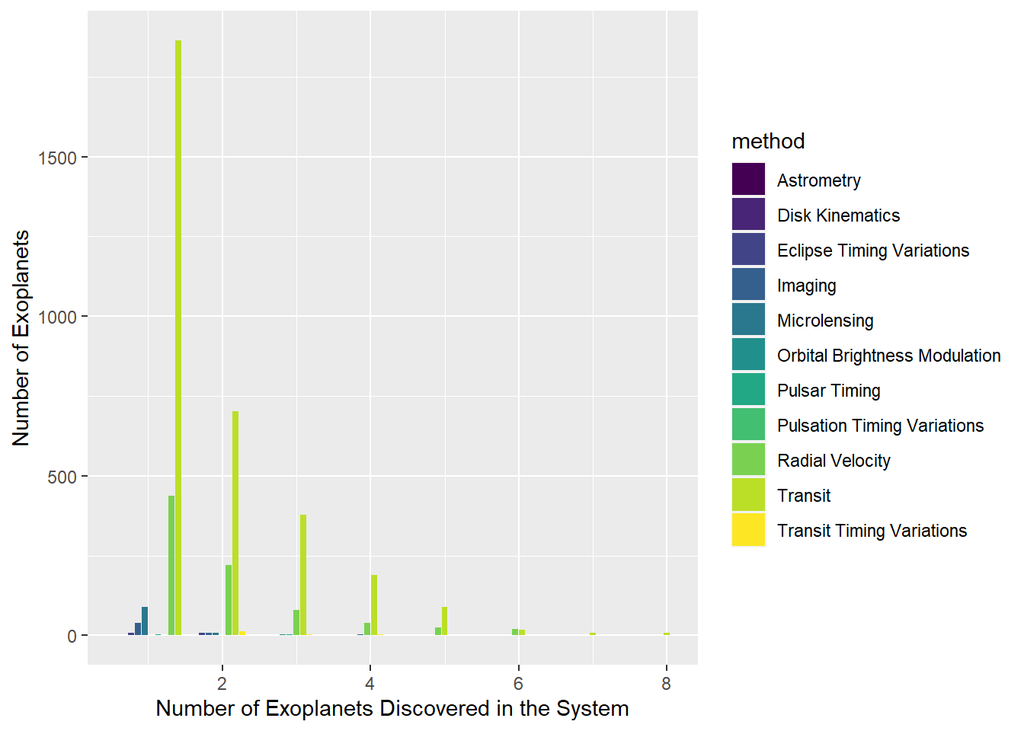

```r
ggplot(planets) +
  geom_bar(mapping = aes(x = number, fill = method), position = position_dodge2(preserve = "single")) +
  labs(x = "Number of Exoplanets Discovered in the System", y = "Number of Exoplanets")
```

What did `position = position_dodge2(preserve = "single")` do to the bar plot? How does it compare to using `position = "dodge"`?

“position_dodge2(preserve =”single“)” creates side-by-side bars and each bar has the same width. “position = dodge” requires each x label has the same width, so some bars are wider than others.

### 4

> The Transit method of detection allows for the estimation of a planet radius and the Radial Velocity method allows for the estimation of a planet’s mass. Create a data frame that counts the number of missing values for the variables `radius` and `mass` for the methods `Transit` and `Radial Velocity`.

```r
planets %>%
  filter(is.na(radius) | is.na(mass)) %>%
  filter(method %in% c("Transit","Radial Velocity")) %>%
  group_by(method) %>%
  summarize(radius_count = sum(is.na(radius)), mass_count = sum(is.na(mass)))
```

```
## # A tibble: 2 x 3
##   method          radius_count mass_count
##   <chr>                  <int>      <int>
## 1 Radial Velocity          806          0
## 2 Transit                   19       2501
```

Are these numbers consistent with the Transit method allowing for the estimation of planet radius and the Radial Velocity method allowing for the estimation of a planet’s mass? Explain.

Yes. Because all of the missing values for the method “Radial Velocity” is the variable “radius”, which cannot be estimated with this method, and most of the missing values for the method “Transit” is the variable “mass”, which cannot be estimated by “Transit”.

### 5

> Calculate the minimum, 25th percentile, mean, median, and maximum value of radius over all exoplanets that were discovered using the method `Transit` in the data set. Be sure to drop the missing values (`drop_na()`) before calculating the summary statistics. You will also need to reduce the data set to the transit method-detected exoplanets before calculating these statistics. To get the 25th percentile, consider using `quantile(radius, .25)`.

```r
planets %>%
  group_by(method) %>%
  summarise(
    count = n(),
    minimum = min(radius, na.rm = TRUE),
    quartile = quantile(radius, .25, na.rm = TRUE),
    mean = mean(radius, na.rm = TRUE),
    median = median(radius, na.rm = TRUE),
    maximum = max(radius, na.rm = TRUE)) %>%
  filter(method == "Transit")
```

```
## # A tibble: 1 x 7
##   method  count minimum quartile  mean median maximum
##   <chr>   <int>   <dbl>    <dbl> <dbl>  <dbl>   <dbl>
## 1 Transit  3253   0.336     1.58  4.16   2.34    23.4
```

Do most of these planets have an estimated radius less than, greater than, or about the same as the radius of the Earth?

Most of these planets have an estimated radius greater than the radius of the Earth.